# Pandas Pivot() Implementation

# Student Behavioral Dataset

About Dataset

Student Performance & Behavior Dataset

- This dataset is real data of 5,000 records collected from a private learning provider.
- The dataset includes key attributes necessary for exploring patterns, correlations, and insights related to academic performance.

Columns:

- Student_ID: Unique identifier for each student.
- First_Name: Student’s first name.
- Last_Name: Student’s last name.
- Email: Contact email (can be anonymized).
- Gender: Male, Female, Other.
- Age: The age of the student.
- Department: Student's department (e.g., CS, Engineering, Business).
- Attendance (%): Attendance percentage (0-100%).
- Midterm_Score: Midterm exam score (out of 100).
- Final_Score: Final exam score (out of 100).
- Assignments_Avg: Average score of all assignments (out of 100).
- Quizzes_Avg: Average quiz scores (out of 100).
- Participation_Score: Score based on class participation (0-10).
- Projects_Score: Project evaluation score (out of 100).
- Total_Score: Weighted sum of all grades.
- Grade: Letter grade (A, B, C, D, F).
- Study_Hours_per_Week: Average study hours per week.
- Extracurricular_Activities: Whether the student participates in extracurriculars (Yes/No).
- Internet_Access_at_Home: Does the student have access to the internet at home? (Yes/No).
- Parent_Education_Level: Highest education level of parents (None, High School, Bachelor's, Master's, PhD).
- Family_Income_Level: Low, Medium, High.
- Stress_Level (1-10): Self-reported stress level (1: Low, 10: High).
- Sleep_Hours_per_Night: Average hours of sleep per night.

The Attendance is not part of the Total_Score or has very minimal weight.

Calculating the weighted sum:

Total Score=a⋅Midterm+b⋅Final+c⋅Assignments+d⋅Quizzes+e⋅Participation+f⋅Projects

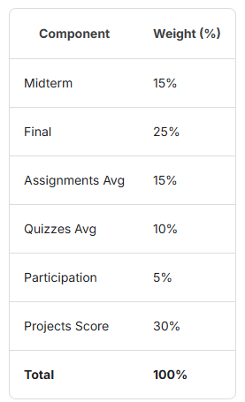

# 1. Import the dataset

```python
import pandas as pd

student = pd.read_csv('Students Performance Dataset.csv')
```

```python
student.head()
```

|  | Student_ID | First_Name | Last_Name | Email | Gender | Age | Department | Attendance (%) | Midterm_Score | Final_Score | ... | Projects_Score | Total_Score | Grade | Study_Hours_per_Week | Extracurricular_Activities | Internet_Access_at_Home | Parent_Education_Level | Family_Income_Level | Stress_Level (1-10) | Sleep_Hours_per_Night |
| --- | --- | --- | --- | --- | --- | --- | --- | --- | --- | --- | --- | --- | --- | --- | --- | --- | --- | --- | --- | --- | --- |
| 0 | S1000 | Omar | Williams | student0@university.com | Female | 22 | Mathematics | 97.36 | 40.61 | 59.61 | ... | 62.84 | 59.8865 | F | 10.3 | Yes | No | Master's | Medium | 1 | 5.9 |
| 1 | S1001 | Maria | Brown | student1@university.com | Male | 18 | Business | 97.71 | 57.27 | 74.00 | ... | 98.23 | 81.9170 | B | 27.1 | No | No | High School | Low | 4 | 4.3 |
| 2 | S1002 | Ahmed | Jones | student2@university.com | Male | 24 | Engineering | 99.52 | 41.84 | 63.85 | ... | 91.22 | 67.7170 | D | 12.4 | Yes | No | High School | Low | 9 | 6.1 |
| 3 | S1003 | Omar | Williams | student3@university.com | Female | 24 | Engineering | 90.38 | 45.65 | 44.44 | ... | 55.48 | 51.6535 | F | 25.5 | No | Yes | High School | Low | 8 | 4.9 |
| 4 | S1004 | John | Smith | student4@university.com | Female | 23 | CS | 59.41 | 53.13 | 61.77 | ... | 87.43 | 71.4030 | C | 13.3 | Yes | No | Master's | Medium | 6 | 4.5 |

5 rows × 23 columns

```python
student.info()
```

```
<class 'pandas.core.frame.DataFrame'>
RangeIndex: 5000 entries, 0 to 4999
Data columns (total 23 columns):
 #   Column                      Non-Null Count  Dtype
---  ------                      --------------  -----
 0   Student_ID                  5000 non-null   object
 1   First_Name                  5000 non-null   object
 2   Last_Name                   5000 non-null   object
 3   Email                       5000 non-null   object
 4   Gender                      5000 non-null   object
 5   Age                         5000 non-null   int64
 6   Department                  5000 non-null   object
 7   Attendance (%)              5000 non-null   float64
 8   Midterm_Score               5000 non-null   float64
 9   Final_Score                 5000 non-null   float64
 10  Assignments_Avg             5000 non-null   float64
 11  Quizzes_Avg                 5000 non-null   float64
 12  Participation_Score         5000 non-null   float64
 13  Projects_Score              5000 non-null   float64
 14  Total_Score                 5000 non-null   float64
 15  Grade                       5000 non-null   object
 16  Study_Hours_per_Week        5000 non-null   float64
 17  Extracurricular_Activities  5000 non-null   object
 18  Internet_Access_at_Home     5000 non-null   object
 19  Parent_Education_Level      3975 non-null   object
 20  Family_Income_Level         5000 non-null   object
 21  Stress_Level (1-10)         5000 non-null   int64
 22  Sleep_Hours_per_Night       5000 non-null   float64
dtypes: float64(10), int64(2), object(11)
memory usage: 898.6+ KB
```

```python
student.shape
```

```
(5000, 23)
```

# 2. Pivot() method in pandas

The pivot() method in Pandas is used to reshape a DataFrame based on values from one or more columns. It takes unique values from specified columns and turns them into new columns, effectively rotating the data from "long" to "wide" format.

Syntax:

DataFrame.pivot(index=None, columns=None, values=None)

Precise Breakdown of pivot() Parameters:

- index (required):
  - This specifies the column (or list of columns) whose unique values will form the new DataFrame's index (rows).
  - If you don't provide this, Pandas will try to use the existing index, but it's usually best to specify it.
  - Each unique combination of values in the index column(s) will become a row in the pivoted table.
- columns (required):
  - This specifies the column (or list of columns) whose unique values will form the new DataFrame's columns.
  - Each unique value (or combination of values) in the columns column(s) will become a column header in the pivoted table.
- values (optional):
  - This specifies the column (or list of columns) whose values will populate the new DataFrame's cells.
  - If values is not specified, pivot() will use all remaining non-index/non-columns columns as the values, and the resulting DataFrame will have a MultiIndex for its columns (level 1 for the original column names, level 2 for the new pivoted column names).
  - If a specific values column is chosen, only its data will be used to fill the cells.

Key Characteristics and How it Works:

- Unique Combinations are Crucial: For pivot() to work correctly, the combination of values specified by index and columns must uniquely identify a single value in the values column for each cell.
  - If there are duplicate combinations of index and columns values (meaning, for a given index-column pair, there are multiple values), pivot() will raise a ValueError: Index contains duplicate entries, cannot reshape.
  - If you have duplicate combinations and need to aggregate the values (e.g., sum them, average them), you should use pivot_table() instead, which is more flexible.
- Reshaping Data: It transforms data from a "long" format (where categories are represented as values in a column) to a "wide" format (where categories become distinct columns).
- Missing Values: If a combination of index and columns values does not exist in the original DataFrame, NaN (Not a Number) will be placed in the corresponding cell of the pivoted table.

When to Use pivot():

- When you have data in a "long" format and want to transform it into a "wide" format.
- When you know that the combination of your chosen index and columns uniquely identifies the values you want in the cells.
- To create a more readable summary table for certain types of data.

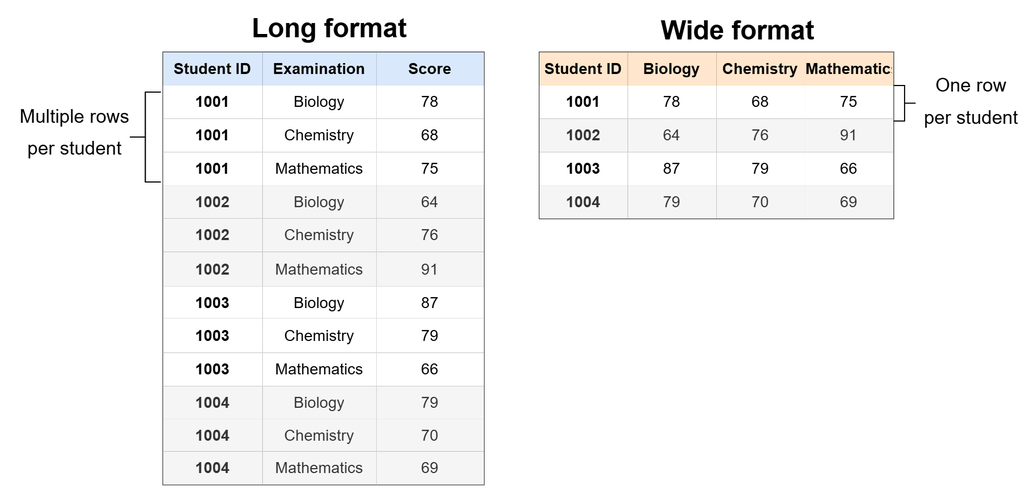

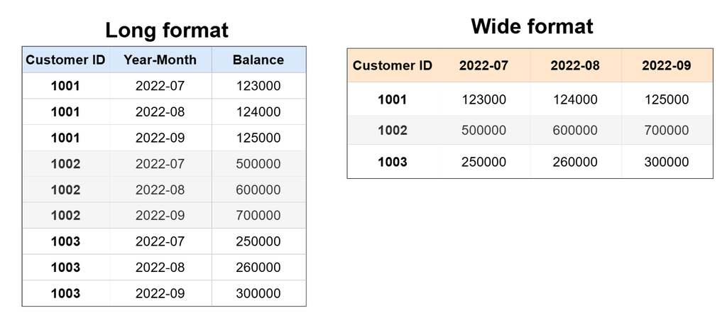

# 3. Data insights leveraging Pivot()

- What are the Midterm_Score and Final_Score for each Student_ID across different Departments?
- What are the Total_Scores for each Student_ID categorized by their Grade?
- What is the Stress_Level for each Student_ID when categorized by their Family_Income_Level?

### A. What are the Midterm_Score and Final_Score for each Student_ID across different Departments?

```python
# Pivot the DataFrame to show Midterm_Score and Final_Score for each Student_ID
# across different Departments.
# 'index' will be the rows (Student_ID).
# 'columns' will be the new columns (Department names).
# 'values' specifies which columns' data will populate the new cells.
# Since we have two value columns, the result will have a MultiIndex for columns.

pivot_scores_by_dept = student.pivot(index='Student_ID', columns='Department', values=['Midterm_Score', 'Final_Score'])

pivot_scores_by_dept
```

| Department Student_ID | Midterm_Score Business | Midterm_Score CS | Midterm_Score Engineering | Midterm_Score Mathematics | Final_Score Business | Final_Score CS | Final_Score Engineering | Final_Score Mathematics |
| --- | --- | --- | --- | --- | --- | --- | --- | --- |
| S1000 | NaN | NaN | NaN | 40.61 | NaN | NaN | NaN | 59.61 |
| S1001 | 57.27 | NaN | NaN | NaN | 74.0 | NaN | NaN | NaN |
| S1002 | NaN | NaN | 41.84 | NaN | NaN | NaN | 63.85 | NaN |
| S1003 | NaN | NaN | 45.65 | NaN | NaN | NaN | 44.44 | NaN |
| S1004 | NaN | 53.13 | NaN | NaN | NaN | 61.77 | NaN | NaN |
| ... | ... | ... | ... | ... | ... | ... | ... | ... |
| S5995 | NaN | 45.86 | NaN | NaN | NaN | 45.63 | NaN | NaN |
| S5996 | NaN | NaN | NaN | 78.67 | NaN | NaN | NaN | 47.42 |
| S5997 | NaN | 50.84 | NaN | NaN | NaN | 65.83 | NaN | NaN |
| S5998 | NaN | NaN | 55.44 | NaN | NaN | NaN | 57.45 | NaN |
| S5999 | NaN | NaN | NaN | 93.29 | NaN | NaN | NaN | 88.42 |

5000 rows × 8 columns

### Explanation for the NaN values : Lets take the 1st row ( student_id : S1000 ) , she is a Mathematics department student so we only have her Midterm_score and Final_Score for Mathematics , all else are NaN)

```python
# Optional: You can fill NaN values if needed, e.g., with 0 or a placeholder

pivot_scores_by_dept_filled = pivot_scores_by_dept.fillna(0)
pivot_scores_by_dept_filled
```

| Department Student_ID | Midterm_Score Business | Midterm_Score CS | Midterm_Score Engineering | Midterm_Score Mathematics | Final_Score Business | Final_Score CS | Final_Score Engineering | Final_Score Mathematics |
| --- | --- | --- | --- | --- | --- | --- | --- | --- |
| S1000 | 0.00 | 0.00 | 0.00 | 40.61 | 0.0 | 0.00 | 0.00 | 59.61 |
| S1001 | 57.27 | 0.00 | 0.00 | 0.00 | 74.0 | 0.00 | 0.00 | 0.00 |
| S1002 | 0.00 | 0.00 | 41.84 | 0.00 | 0.0 | 0.00 | 63.85 | 0.00 |
| S1003 | 0.00 | 0.00 | 45.65 | 0.00 | 0.0 | 0.00 | 44.44 | 0.00 |
| S1004 | 0.00 | 53.13 | 0.00 | 0.00 | 0.0 | 61.77 | 0.00 | 0.00 |
| ... | ... | ... | ... | ... | ... | ... | ... | ... |
| S5995 | 0.00 | 45.86 | 0.00 | 0.00 | 0.0 | 45.63 | 0.00 | 0.00 |
| S5996 | 0.00 | 0.00 | 0.00 | 78.67 | 0.0 | 0.00 | 0.00 | 47.42 |
| S5997 | 0.00 | 50.84 | 0.00 | 0.00 | 0.0 | 65.83 | 0.00 | 0.00 |
| S5998 | 0.00 | 0.00 | 55.44 | 0.00 | 0.0 | 0.00 | 57.45 | 0.00 |
| S5999 | 0.00 | 0.00 | 0.00 | 93.29 | 0.0 | 0.00 | 0.00 | 88.42 |

5000 rows × 8 columns

### B. What are the Total_Scores for each Student_ID categorized by their Grade?

```python
# Pivot the DataFrame to show Total_Scores for each Student_ID categorized by their Grade.
# 'index' will be the rows (Student_ID).
# 'columns' will be the new columns (Grade values like 'A', 'B', 'C').
# 'values' specifies the column whose data will populate the new cells.

pivot_total_scores_by_grade = student.pivot(
    index='Student_ID',
    columns='Grade',
    values='Total_Score'
)
```

```python
pivot_total_scores_by_grade
```

| Grade Student_ID | A | B | C | D | F |
| --- | --- | --- | --- | --- | --- |
| S1000 | NaN | NaN | NaN | NaN | 59.8865 |
| S1001 | NaN | 81.917 | NaN | NaN | NaN |
| S1002 | NaN | NaN | NaN | 67.7170 | NaN |
| S1003 | NaN | NaN | NaN | NaN | 51.6535 |
| S1004 | NaN | NaN | 71.4030 | NaN | NaN |
| ... | ... | ... | ... | ... | ... |
| S5995 | NaN | NaN | NaN | NaN | 53.5470 |
| S5996 | NaN | NaN | NaN | NaN | 59.0240 |
| S5997 | NaN | NaN | 74.7560 | NaN | NaN |
| S5998 | NaN | NaN | NaN | 68.6585 | NaN |
| S5999 | NaN | NaN | 78.7485 | NaN | NaN |

5000 rows × 5 columns

```python
# Optional: You can fill NaN values if a student does not have a score for a particular grade
# For example, fill with 0 or a placeholder

pivot_total_scores_by_grade_filled = pivot_total_scores_by_grade.fillna(0)
pivot_total_scores_by_grade_filled
```

| Grade Student_ID | A | B | C | D | F |
| --- | --- | --- | --- | --- | --- |
| S1000 | 0.0 | 0.000 | 0.0000 | 0.0000 | 59.8865 |
| S1001 | 0.0 | 81.917 | 0.0000 | 0.0000 | 0.0000 |
| S1002 | 0.0 | 0.000 | 0.0000 | 67.7170 | 0.0000 |
| S1003 | 0.0 | 0.000 | 0.0000 | 0.0000 | 51.6535 |
| S1004 | 0.0 | 0.000 | 71.4030 | 0.0000 | 0.0000 |
| ... | ... | ... | ... | ... | ... |
| S5995 | 0.0 | 0.000 | 0.0000 | 0.0000 | 53.5470 |
| S5996 | 0.0 | 0.000 | 0.0000 | 0.0000 | 59.0240 |
| S5997 | 0.0 | 0.000 | 74.7560 | 0.0000 | 0.0000 |
| S5998 | 0.0 | 0.000 | 0.0000 | 68.6585 | 0.0000 |
| S5999 | 0.0 | 0.000 | 78.7485 | 0.0000 | 0.0000 |

5000 rows × 5 columns

### C. What is the Stress_Level for each Student_ID when categorized by their Family_Income_Level?

```python
# Pivot the DataFrame to show Stress_Level for each Student_ID
# categorized by their Family_Income_Level.
# 'index' will be the rows (Student_ID).
# 'columns' will be the new columns (Family_Income_Level categories).
# 'values' specifies the column whose data will populate the new cells.

pivot_stress_level_by_income = student.pivot(
    index='Student_ID',
    columns='Family_Income_Level',
    values='Stress_Level (1-10)'
)
```

```python
pivot_stress_level_by_income
```

| Family_Income_Level Student_ID | High | Low | Medium |
| --- | --- | --- | --- |
| S1000 | NaN | NaN | 1.0 |
| S1001 | NaN | 4.0 | NaN |
| S1002 | NaN | 9.0 | NaN |
| S1003 | NaN | 8.0 | NaN |
| S1004 | NaN | NaN | 6.0 |
| ... | ... | ... | ... |
| S5995 | NaN | NaN | 10.0 |
| S5996 | NaN | NaN | 4.0 |
| S5997 | 5.0 | NaN | NaN |
| S5998 | NaN | NaN | 10.0 |
| S5999 | 2.0 | NaN | NaN |

5000 rows × 3 columns

```python
# Optional: You can fill NaN values if a student does not have a stress level
# for a particular income category (e.g., if they only appear under 'Low' income).
# For example, fill with a placeholder like 0 or None.

pivot_stress_level_by_income_filled = pivot_stress_level_by_income.fillna(0)

pivot_stress_level_by_income_filled
```

| Family_Income_Level Student_ID | High | Low | Medium |
| --- | --- | --- | --- |
| S1000 | 0.0 | 0.0 | 1.0 |
| S1001 | 0.0 | 4.0 | 0.0 |
| S1002 | 0.0 | 9.0 | 0.0 |
| S1003 | 0.0 | 8.0 | 0.0 |
| S1004 | 0.0 | 0.0 | 6.0 |
| ... | ... | ... | ... |
| S5995 | 0.0 | 0.0 | 10.0 |
| S5996 | 0.0 | 0.0 | 4.0 |
| S5997 | 5.0 | 0.0 | 0.0 |
| S5998 | 0.0 | 0.0 | 10.0 |
| S5999 | 2.0 | 0.0 | 0.0 |

5000 rows × 3 columns

# Key Insights

- The pivot() method in Pandas is excellent for reshaping data from a "long" to a "wide" format, effectively rotating values from specific columns into new column headers while precisely retaining the original data points.
- However, its most significant drawback, is its inability to perform aggregation on numeric data. This means that if a combination of the chosen index and columns values in your original DataFrame leads to multiple corresponding values entries, pivot() cannot resolve this ambiguity by summing, averaging, or performing any other statistical operation. Instead, it will raise an error (a ValueError indicating duplicate entries).
- Given that a key aspect of data analysis involves grouping data and deriving summary statistics through aggregation, this limitation restricts pivot() solely to scenarios where you're reshaping data without any need to summarize or combine original values. To overcome this fundamental limitation, Pandas provides the more versatile pivot_table() method, which is specifically designed to handle both data reshaping and the aggregation of numeric data simultaneously.